# Wyjaśnienie nt. $R^2$

Paweł Lonca

03.11.2018

## Dane

Załóżmy, że posiadamy następuje dane:

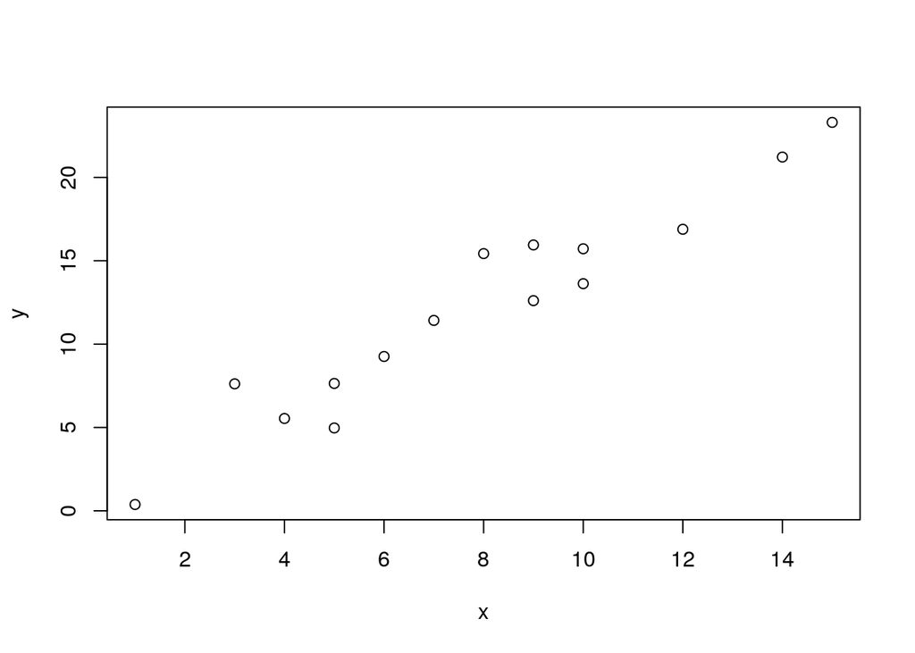

```r
set.seed(123)
x <- c(1, 4, 3, 5, 6, 8, 7, 5, 10, 9, 9, 10, 15, 14, 12)
y <- 1.5*x + rnorm(15, 0, 2)
dane <- data.frame(y = y, x = x)
plot(x,y)
```

Naszym zadaniem jest znalezienie związku między zmienną $x$ (`dane$x`), którą nazywamy niezależną, a zmienną $y$ (`dane$y`), którą nazywamy zależną. Zmienna niezależna jest podstawą do przewidzenia wartości zmiennej zależnej. Na początku warto zbadać czy występuje pomiędzy nimi (liniowa) współzależność. Okazuje się, że współczynnik korelacji liniowej Pearsona wynosi:

```r
cor(dane$x, dane$y)
```

```
## [1] 0.9631779
```

### Metody

#### Pojedyncza wartość

Jedną ze strategii rozwiązania problemu określania wartości zmiennej $y$ przez model byłoby podawanie za każdym razem jako odpowiedzi tej samej wartości zmiennej $y$. Może to być średnia, mediana, maksimum, minimum lub jakakolwiek inna pojedyncza wartość. Nie stosujemy dominanty, ponieważ zmienna $y$ jest ciągła. Dodajmy odpowiednie wartości do ramki danych:

```r
y_srednia <- rep(mean(dane$y), nrow(dane))
y_mediana <- rep(median(dane$y), nrow(dane))
y_max <- rep(max(dane$y), nrow(dane))
y_min <- rep(min(dane$y), nrow(dane))
y_los <- rep(42, nrow(dane))
dane <- cbind(dane, y_srednia, y_mediana, y_max, y_min, y_los)
kable(dane)
```

| y | x | y_srednia | y_mediana | y_max | y_min | y_los |
| --- | --- | --- | --- | --- | --- | --- |
| 0.3790487 | 1 | 12.10477 | 12.60868 | 23.30154 | 0.3790487 | 42 |
| 5.5396450 | 4 | 12.10477 | 12.60868 | 23.30154 | 0.3790487 | 42 |
| 7.6174166 | 3 | 12.10477 | 12.60868 | 23.30154 | 0.3790487 | 42 |
| 7.6410168 | 5 | 12.10477 | 12.60868 | 23.30154 | 0.3790487 | 42 |
| 9.2585755 | 6 | 12.10477 | 12.60868 | 23.30154 | 0.3790487 | 42 |
| 15.4301300 | 8 | 12.10477 | 12.60868 | 23.30154 | 0.3790487 | 42 |
| 11.4218324 | 7 | 12.10477 | 12.60868 | 23.30154 | 0.3790487 | 42 |
| 4.9698775 | 5 | 12.10477 | 12.60868 | 23.30154 | 0.3790487 | 42 |
| 13.6262943 | 10 | 12.10477 | 12.60868 | 23.30154 | 0.3790487 | 42 |
| 12.6086761 | 9 | 12.10477 | 12.60868 | 23.30154 | 0.3790487 | 42 |
| 15.9481636 | 9 | 12.10477 | 12.60868 | 23.30154 | 0.3790487 | 42 |
| 15.7196277 | 10 | 12.10477 | 12.60868 | 23.30154 | 0.3790487 | 42 |
| 23.3015429 | 15 | 12.10477 | 12.60868 | 23.30154 | 0.3790487 | 42 |
| 21.2213654 | 14 | 12.10477 | 12.60868 | 23.30154 | 0.3790487 | 42 |
| 16.8883177 | 12 | 12.10477 | 12.60868 | 23.30154 | 0.3790487 | 42 |

#### Zgadywanie

Mówi się, że modele, które są uproszczeniami (lub idealizacjami) rzeczywistości zgadują wartość zmiennych zależnych. Idąc tym tropem niech model poproszony o określenie wartości $y$ podaje losową liczbę z rozkładu, który parametrami odpowiada rozkładowi zmiennej $y$. Jest to przypadek `y_zgaduj1`. Natomiat zmienna `y_zgaduj2` trzyma 15 wartości z rozkładu $N(0,2)$. Jest to podejście inne w stosunku do poprzednich, ponieważ za każdym razem zwracana jest inna wartość:

```r
y_zgaduj1 <- rnorm(nrow(dane), mean(dane$y), sd(dane$y))
y_zgaduj2 <- rnorm(nrow(dane), 0, 2)
dane <- cbind(dane, y_zgaduj1, y_zgaduj2)
kable(dane)
```

| y | x | y_srednia | y_mediana | y_max | y_min | y_los | y_zgaduj1 | y_zgaduj2 |
| --- | --- | --- | --- | --- | --- | --- | --- | --- |
| 0.3790487 | 1 | 12.10477 | 12.60868 | 23.30154 | 0.3790487 | 42 | 23.3349066 | 0.8529284 |
| 5.5396450 | 4 | 12.10477 | 12.60868 | 23.30154 | 0.3790487 | 42 | 15.2335887 | -0.5901430 |
| 7.6174166 | 3 | 12.10477 | 12.60868 | 23.30154 | 0.3790487 | 42 | -0.2547476 | 1.7902513 |
| 7.6410168 | 5 | 12.10477 | 12.60868 | 23.30154 | 0.3790487 | 42 | 16.5125507 | 1.7562670 |
| 9.2585755 | 6 | 12.10477 | 12.60868 | 23.30154 | 0.3790487 | 42 | 9.1334364 | 1.6431622 |
| 15.4301300 | 8 | 12.10477 | 12.60868 | 23.30154 | 0.3790487 | 42 | 5.3938619 | 1.3772805 |
| 11.4218324 | 7 | 12.10477 | 12.60868 | 23.30154 | 0.3790487 | 42 | 10.7348709 | 1.1078353 |
| 4.9698775 | 5 | 12.10477 | 12.60868 | 23.30154 | 0.3790487 | 42 | 5.6566816 | -0.1238234 |
| 13.6262943 | 10 | 12.10477 | 12.60868 | 23.30154 | 0.3790487 | 42 | 7.5239366 | -0.6119253 |
| 12.6086761 | 9 | 12.10477 | 12.60868 | 23.30154 | 0.3790487 | 42 | 8.1766106 | -0.7609420 |
| 15.9481636 | 9 | 12.10477 | 12.60868 | 23.30154 | 0.3790487 | 42 | 1.5044781 | -1.3894140 |
| 15.7196277 | 10 | 12.10477 | 12.60868 | 23.30154 | 0.3790487 | 42 | 17.3699737 | -0.4158346 |
| 23.3015429 | 15 | 12.10477 | 12.60868 | 23.30154 | 0.3790487 | 42 | 13.0686663 | -2.5307927 |
| 21.2213654 | 14 | 12.10477 | 12.60868 | 23.30154 | 0.3790487 | 42 | 4.9519673 | 4.3379119 |
| 16.8883177 | 12 | 12.10477 | 12.60868 | 23.30154 | 0.3790487 | 42 | 19.9845667 | 2.4159240 |

### Dokładność modelu

Chcąc obliczyć to jak model się myli w przewidywaniu zmiennej $y$ obliczamy sumę kwadratów różnic pomiędzy wartością zaobserwowaną $y_i$ (`dane$y`) a wartością zwróconą przez model $\hat{y}_i$ (np. `dane$y_zgaduj1`). Stosujemy kwadraty, ponieważ nie interesuje nas, w którą stronę model się pomylił, a większe bezwzględne pomyłki powinny być mocniej karane niż mniejsze bezwzględne pomyłki:

$\large{\sum_{i}^{n}{(y_i - \hat{y}_i)^2}}$, gdzie $n$ to liczba obserwacji

Zwróćmy szczególną uwagę na błąd modelu obliczony dla średniej, który dany jest wzorem:

$\large{\sum_i^n{(y_i - \bar{y})}}$, gdzie $\bar{y}$ to wartość średnia.

W definiowaniu $R^2$ jest to poziom wyjściowy błędu, czyli innymi słowy jak bardzo niedokładnie przewiduje model w jednym z najgorszych możliwych wypadków. Z tego powodu poprzedni wzór jest przypisywany do oddzielnej zmiennej:

$\large{SS_{total} = \sum_i^n{(y_i - \bar{y})}}$

$SS_{total}$ można przedstawić w następującej postaci:

$\large{\sum_i^n{(y_i - \hat{y}_i + \hat{y}_i - \bar{y})^2}}$

Zapisany w innej postaci:

$\large{SS_{total} = \sum_i^n ( y_i - \hat { y }_i ) ^ { 2 } + 2 * \sum_i^n ( y_i - \hat { y }_i ) ( \hat { y }_i - \overline { y }_i ) + \sum_i^n ( \hat { y }_i - \overline { y }_i ) ^ { 2 }}$

Gdy rozważamy model liniowy z wyrazem wolnym różnym od zera, zachodzi:

$\large{2 * \sum ( y_i - \hat { y }_i ) ( \hat { y }_i - \overline { y }_i ) = 0}$

co daje następującą postać całkowitego błędu modelu:

$\large{SS_{total}= \sum_i^n ( y_i - \hat { y }_i ) ^ { 2 } + \sum_i^n ( \hat { y }_i - \overline { y }_i ) ^ { 2 }}$

Zwróćmy uwagę na pierszy składnik, czyli $\sum_i^n ( y_i - \hat { y }_i ) ^ { 2 }$, który mówi nam jak (sumarycznie) przewidywania modelu są oddalone od rzeczywistych obserwacji. Wprowadźmy inny zapis tego składnika:

$\large{SS_{res} = \sum_i^n ( y_i - \hat { y }_i ) ^ { 2 } = \sum_i^n e _ { i } ^ { 2 }}$

Współczynnik $R^2$ możemy wtedy zdefiniować następująco:

$\large{R^2 = 1 - \frac{SS_{res}}{SS_{total}}}$

Sprawdźmy ile wynosi błąd modelu zdefiniownay jako $SS_{total}$:

```r
(SS_tot <- sum((dane$y - dane$y_srednia)^2))
```

```
## [1] 552.957
```

Dla pozostałych dotychczas uzyskanych modeli (które są de facto pojedynczą wartością poza `dane$y_zgaduj1` i `dane$y_zgaduj2`) liczymy $SS_{res}$:

```r
errors <- lapply(dane[, 4:ncol(dane)], FUN = function(x){sum(dane$y - x)^2})
names(errors) <- errors %>% names() %>% lapply(function(x){gsub("y_", "blad_", x)})
errors
```

```
## $blad_mediana
## [1] 57.1326
##
## $blad_max
## [1] 28207.74
##
## $blad_min
## [1] 30935.81
##
## $blad_los
## [1] 201088.1
##
## $blad_zgaduj1
## [1] 540.385
##
## $blad_zgaduj2
## [1] 29829.73
```

Biorąc pod uwagę podany wcześniej wzór na $R^2$ możemy spodziewać się wartości 1, w sytuacji idealnego dopasowania, natomiast wartości równej 0, gdy model popełnia (wartościowo) tyle samo błędów co przewidywanie średnią. Jednak błędy dla niektórych modeli są wyższe od wartości 552.9569677, co oznacza, że możemy spodziewać się $R^2$ mniejszego od zera:

```r
R_kwadrat <- lapply(errors, FUN=function(x){1-x/SS_tot})
R_kwadrat
```

```
## $blad_mediana
## [1] 0.896678
##
## $blad_max
## [1] -50.01255
##
## $blad_min
## [1] -54.94615
##
## $blad_los
## [1] -362.6596
##
## $blad_zgaduj1
## [1] 0.02273594
##
## $blad_zgaduj2
## [1] -52.94584
```

$R^2$ osiąga wartości poniżej zera w następujących przypadkach: model przewiduje jedną arbitralnie wybraną przez nas wartość jak w `dane$y_los` (tutaj 42), model zawsze przewiduje maksymalną lub minimalną wartość `dane$y` oraz gdy model losowo wybiera wartość z $N(0,2)$. Ujemna wartość $R^2$ może wystąpić i jej zadaniem jest informowanie osoby przeprowadzającej analizę, że wybrała niewłaściwy model, czyli taki, który radzi sobie gorzej w przewidywaniu niż model oparty na średniej.

### Zmienna niezależna

W zadaniu przewidywania wartości zmiennej $y$ może pomóc zmienna niezależna $x$, z którą zmienna zależna jest skorelowana. Tworzymy model liniowy:

```r
model_liniowy <- lm(y ~ x, data = dane)
```

który dany jest równaniem:

$$y_i = 0.19 + 1.51 x_i$$

Błąd $SS_{res}$ w przypadku modelu liniowego wynosi odpowiednio:

```r
(SS_res_lm <- sum((dane$y - model_liniowy$fitted.values)^2))
```

```
## [1] 39.97233
```

natomiast $R^2$ wynosi:

```r
1 - SS_res_lm/SS_tot
```

```
## [1] 0.9277117
```

Wartość $R^2$ dla tego modelu liniowego jest bliska 1, ale zastanówmy się kiedy $R^2$ może wynieść 1 (lub przekroczyć tą wartość). Aby osiągnąć 1 model musi przewidywać dokładnie te wartości, które zaszły w rzeczywistości. Wtedy suma kwadratów $SS_{res}$ będzie równa 0. W przypadku zestawu `dane` jest to niemożliwe ze względu na sposób w jaki wygenerowane są wartości $y$:

$y_i = 1.5x_i + \epsilon_i$, gdzie $\epsilon_i$ pochodzi z rozkładu $N(0,2)$.

Wartość $R^2$ nie może być większa od 1, ponieważ ułamek $\large{\frac{SS_{res}}{SS_{total}}}$ musiałby być ujemny. Jest to niemożliwe ponieważ zarówno w liczniku jak i mianowniku są sumy kwadratów.

### Podsumowanie

Wartość $R^2$ nie może przekroczyć 1. Kwestia tego czy ten współczynnik może być mniejszy od zera zależy od tego w jaki sposób zdefiniujemy najgorszy z możliwych modeli. Przyjęło się, że najgorszy możliwy model to taki zawsze zwracający średnią zmiennej zależnej. W powyższej analizie sprawdziliśmy inne nierozsądne modele i okazuje się, że są jeszcze gorsze od modelu ze średnią. Najgorzej wypadł *blad_los* z błędem 201088.1. Gdybyśmy policzyli $SS_{tot}$ według tego modelu to nie otrzymalibyśmy wartości $R^2$ mniejszej od zera.